01

Journal Reading · V2 · 主軸 ACS / Efient (Prasugrel)

# 在 AI 時代運用人工智慧 進行文獻回顧

Leveraging Artificial Intelligence for Literature Review in the Age of AI

Claude CodeMCP Scientific SkillsPrompt Engineering

All slides built with Claude Code — an AI agent for medical education

00

## Why I Turned to AI

序章 · 中風與長時間閱讀能力的妥協

序章 · My Story（1/2）

## 2023-01-26：枕葉的缺血性中風

- **那一天，我自己成了病人。****枕葉 (occipital lobe)** 的 **缺血性中風 (ischemic stroke) from migraine attack**.
- 它讓我的 **視野 (visual field)** 與 **長時間閱讀的能力** 受到明顯影響。
- 以前很習慣閱讀大量文獻... 後來真的不能長時間閱讀了...
- 右側為本人的腦部 MRI, axial and sagittal views.

  MRA found spasm of Rt PCA, and the Rt PCA vessle diameter returned to normal at 1 month follow-up MRA.

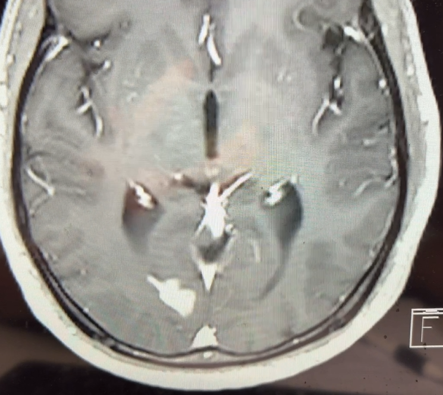

Brain MRI ① · 軸狀/矢狀面

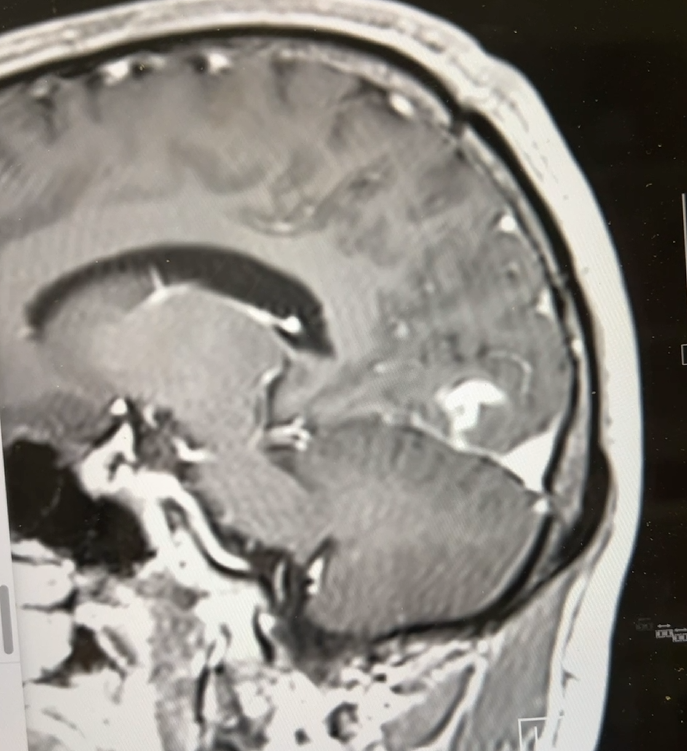

Brain MRI ② · 軸狀/矢狀面

謝慕揚 MD, PhD, FESC · 我的故事 · 2023 枕葉中風

序章 · My Story（2/2）

## 從病人視角，找回 閱讀的能力

- 自己的TEE自己塞。
- 之後閱讀長篇 PDF 變得異常吃力。我開始尋找「讓我重新跟上文獻」的方法。
- 答案是 **AI**：先用朗讀與摘要，後來用 **Claude、Claude Code 與多 agent**，把「讀」與「整理」交給工具。
- 我把有限的視力做最大運用。
- 這就是我走進 AI 文獻回顧的起點——不是因為新潮，而是因為 **必要**。

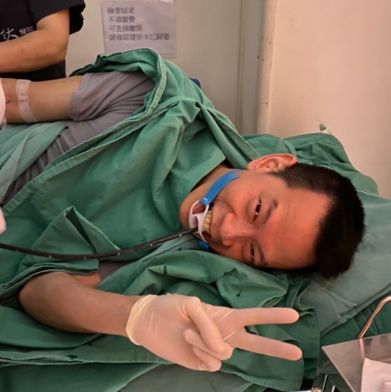

我接受 TEE（經食道超音波）· Receiving a TEE · 從醫師到病人

謝慕揚 MD, PhD, FESC · 從病人視角出發的 AI 之路

What's New

## In today's sharing

~/journal-reading — git log --oneline

❯ git log --oneline v1..v2

a3f1c 範例全面換軸：TEER/TAVI → ACS + Efient

7b9e2 三個臨床範例全部與 prasugrel 相關

c4d80 新增 Claude 文獻回顧 詳細步驟

e1a55 新增 Prompt Engineering 章節

f8c30 大幅擴充 Scientific Skills

✓ 臨床工作坊版

- **範例:** **ACS + Efient (prasugrel)** 為主軸
- **三個臨床範例**：ISAR-REACT 5、de-escalation、special populations
- **重點強化**：Claude 文獻回顧步驟、如何寫 prompt、Scientific Skills

謝慕揚 MD, PhD, FESC · V2 · ACS / Efient · 2026

Outline · 八個章節

## 今天的 路線圖

~/talk — tree -L 1 outline/

❯ tree outline/

outline/

├── 1_why/ 年輕醫師的閱讀困境

├── 2_journey/ ChatGPT→Claude.ai→Code

├── 3_code_mcp/ 兩個核心引擎

├── 4_skills/ ★ 科研工具箱（擴充）

├── 5_prompts/ ★ 提示詞工程（全新）

├── 6_examples/ ★ 三個 ACS/Efient 實例

├── 7_pitfalls/ 驗證・幻覺・版權

└── 8_takeaways/ 你明天就能開始

01

#### WHY

文獻供給 ≫ 人類閱讀速度

02

#### JOURNEY

我的 AI 工具演進史

03

#### CODE · MCP

agent + 外接資料庫

04 ★

#### SKILLS

把 Claude 當研究助理

05 ★

#### PROMPTS

把投影片磨亮

06 ★

#### EXAMPLES

ISAR-REACT 5 等三例

謝慕揚 MD, PhD, FESC · V2 · ACS / Efient · 2026

01

## Why AI for Literature Review?

為什麼年輕醫師需要 AI 幫忙讀文獻

Part 1 · 真實處境

## 文獻產出速度 ≫ 人類閱讀速度

80+

小時 / 週  
查房・門診・值班・會議・教學

3,600萬+

PubMed 已索引生醫文獻

150萬

每年新增篇數

50+

六大期刊每週原著論文

claude — mcp__pubmed__search (count)

❯ pubmed.count("acute coronary syndrome AND antiplatelet",

date="2021:2026")

→ retrieving …

⟶ 12,000+ articles 過去 5 年，單一主題

- 剩下讀文獻的時間 → 通勤、睡前、週末
- 想完整跟上 cardiology 文獻 → 完全不可能
- 光 ACS / antiplatelet 一個主題就 **讀不完**

謝慕揚 MD, PhD, FESC · V2 · ACS / Efient · 2026

Part 1 · 為什麼選這個藥當主軸

## 以 Efient (Prasugrel) 為例的文獻量壓力

- **臨床高度相關**：所有 cath lab 的 ACS / PCI 病人都會接觸
- **文獻爭議多**：vs ticagrelor、de-escalation、elderly、Asian dose
- **指引快速演進**：2023 ESC ACS guideline 已改 default P2Y12 推薦
- **每年新增 ~600 篇** prasugrel 相關 paper

三條切片 — three slices to demonstrate

❯ slices --drug prasugrel

[1] 頭對頭比較 ISAR-REACT 5

[2] 降階治療 TROPICAL · TOPIC · HOST-REDUCE

[3] 特殊族群 ELDERLY-ACS 2 · POPular AGE · Asian

⚠ 沒有 AI，要串起這三條線 ≥ 兩個週末

謝慕揚 MD, PhD, FESC · V2 · ACS / Efient · 2026

Part 1 · 典範轉移

## 傳統 vs AI 時代的文獻回顧

| 面向 | 傳統做法 | AI 時代做法 |
| --- | --- | --- |
| **搜尋** | 手動 Boolean query，反覆試 | 自然語言描述問題，AI 迭代優化 |
| **篩選** | 一篇篇看標題與摘要 | 批次相關性評分 + 關鍵句擷取 |
| **閱讀** | 單篇深讀，耗時數小時 | 跨篇 synthesize，保留 citation |
| **整理** | 手動做表格、手寫 summary | 結構化表格 + 自動 citation export |
| **教學** | 做 slides → 另一輪工作 | 同一 workflow 自動產出講義 + 投影片 |

謝慕揚 MD, PhD, FESC · V2 · ACS / Efient · 2026

Part 1 · 關鍵 mindset shift

## 醫師：從搜尋者 → 策略師 + 驗證者

before-ai.log

# Before AI

我 → 花 3 小時讀一篇 ISAR-REACT 5

→ 勉強弄懂

→ 沒時間做筆記

after-ai.log

# After AI · ~90 min 完整 workflow

❯ ask "Prasugrel vs Ticagrelor in ACS"

✓ 搜尋 · 全文擷取 · 提取 endpoints

✓ 我 review / challenge HR·CI·p

✓ 產出 講義 + 投影片 + 郵件

謝慕揚 MD, PhD, FESC · V2 · ACS / Efient · 2026

02

## The Journey

我的 AI 工具演進史：ChatGPT → Claude.ai → Claude Code

Stage 1 · 2023

## ChatGPT 時代 — 對系統性回顧完全不夠

chat.openai.com — 2023

你：把這段 NEJM abstract 翻譯 + 整理

AI：好的，以下是整理…

⚠ 編造了一個不存在的 citation

⚠ 無法存取真實 PubMed

⚠ 只能 copy-paste，無法處理檔案

- 把 abstract 貼進去 → 翻譯 + 整理
- 請它解釋統計方法（如 hierarchical composite endpoint）
- 問疾病的 differential diagnosis

對**短問答**有用；產出無法直接用於教學（格式要手動重做）。

謝慕揚 MD, PhD, FESC · V2 · ACS / Efient · 2026

Stage 2 · 2024

## Claude.ai 網頁版 — Projects + Artifacts

- 仍無法真正「搜尋」PubMed，只能處理上傳的 PDF
- 每次對話有 context 限制
- 產出仍要手動整理、存檔、排版
- 無法執行 code / shell command

claude.ai — Project: ACS antiplatelet

📎 ISAR-REACT-5.pdf uploaded

📎 bRIGHT-subgroup.pdf uploaded

你：做一張 evidence table

▣ Artifact → Markdown table 產生

轉捩點：2024-11 Anthropic 推出 MCP

謝慕揚 MD, PhD, FESC · V2 · ACS / Efient · 2026

Stage 3 · 2025 – 現在

## Claude Code — 從聊天機器人變成 AI agent

drake@cvlab : ~/journal-reading — claude

❯ claude "每週把當期 Circulation 的 ACS 文章整理成中文講義"

✓ mcp__pubmed__search # 搜尋本週 Circulation ACS

✓ mcp__pubmed__fetch_articles # 擷取全文 / abstract

✓ Write handouts/01-ischemic-heart-disease/weekly.md

✓ Bash marp --pdf weekly_Marp.md # 投影片 + PDF

✓ git commit -m "weekly ACS review" && push

⚙

#### 讀寫檔案 · 執行指令

直接在電腦上操作，存檔、推 Git

🔌

#### 呼叫 MCP servers

PubMed · Semantic Scholar · CT.gov · ClinPGx

♻

#### 每週一個 workflow

搜尋→閱讀→整理→投影片→郵件 全自動

謝慕揚 MD, PhD, FESC · V2 · ACS / Efient · 2026

真實工作畫面 · Real Workflow（非示意圖）

## 四個 Claude Terminal 平行作業 · 交叉監督

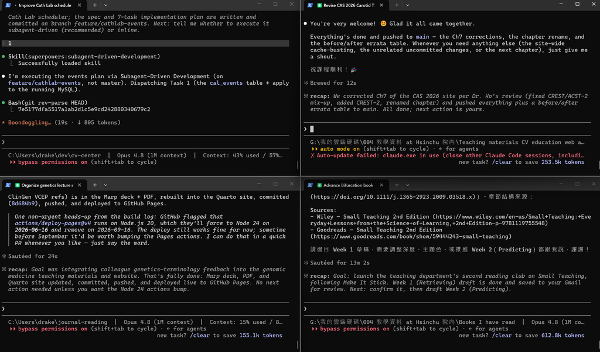

① Cath Lab 排程② CAS 2026 頸動脈網頁校訂 ③ 基因醫學講義④ Bifurcation 讀書會 全程 Opus 4.8 · 1M context

四個 agent 同時產出不同教材，並互相 review／交叉監督 · 謝慕揚 MD, PhD, FESC

03

## Claude Code & MCP

兩個核心引擎：agent + 外接的醫學資料庫

Part 3 · 三句話說明

## Claude Code — 你不需要會寫 code

- **Anthropic 官方 CLI**，把 Claude 模型直接放進終端機
- 不是聊天框，而是**可執行操作**的 AI agent
- 你給它一個 **CLAUDE.md** → 它自動遵循你的工作流程
- 產出皆**可重複、可追蹤、可分享**（檔案 / Git / Markdown / PDF）

~/journal-reading — cat CLAUDE.md

❯ cat CLAUDE.md

# 工作流程：醫學文獻 → 雙語講義

語言：繁體中文 + 保留英文藥名

引用：Vancouver + PubMed/DOI 連結

輸出：講義.md + Marp + PDF

作者：謝慕揚 MD, PhD, FESC

→ 一次定義，之後每次自動執行

謝慕揚 MD, PhD, FESC · V2 · ACS / Efient · 2026

Part 3 · Model Context Protocol

## MCP = Claude 這位研究助理的 USB 接口

- **Anthropic 2024-11** 發布的開放標準
- 標準化 AI ↔ 外部工具（API、DB、檔案系統）的溝通
- 任何人都能寫 server → 生態系快速膨脹

意義：Claude 不再被困在對話框，可直接操作真實世界的醫學資料庫。

🤖 Claude（研究助理）

▏

MCP · USB 接口

╱ │ ╲

PubMedSemantic ScholarClinicalTrials.gov ClinPGxZoteroGmailGit

謝慕揚 MD, PhD, FESC · V2 · ACS / Efient · 2026

Part 3 · 每天在用的 MCP Servers

## 我的 MCP 清單 — 在 ACS / Efient 的角色

| MCP Server | 功能 | 在 Efient 範例的角色 |
| --- | --- | --- |
| **PubMed** | 3,600 萬筆生醫文獻 | ISAR-REACT 5、TROPICAL-ACS 全文檢索 |
| **Semantic Scholar** | 2 億篇 + citation graph | 找 prasugrel 領域 key papers / h-index |
| **bioRxiv / medRxiv** | 預印本 | 最新 ACS guideline、機轉研究 |
| **ClinicalTrials.gov** | 註冊試驗資料 | 確認 NCT、追進行中試驗 |
| **ClinPGx** (PharmGKB) | CYP2C19 / 藥物基因 | 解讀 prasugrel vs clopidogrel 在 LOF 病人 |
| **Zotero** | 書目管理 | 匯出 BibTeX、整理 citation |
| **Gmail / Calendar / GitHub** | 工作流自動化 | 草稿 email、行事曆、版本控管 |

謝慕揚 MD, PhD, FESC · V2 · ACS / Efient · 2026

04

## Scientific Skills

Claude 內建的「科研工具箱」 ★

Part 4 · 定義

## Skill = 打包好的研究流程（結構化 prompt + 工具組合）

claude — invoke skill

❯ skill literature-review

▶ Launching skill: literature-review

載入方法論：PICO + PRISMA

自動串接：PubMed · CT.gov · S2

輸出規格：evidence table + gap analysis

- 呼叫名字（如 literature-review）→ 自動套用其方法論
- **可重複**：每次回顧都遵循同一套流程
- **內含領域知識**：知道要用 PRISMA / PICO
- **與 MCP 自動串接**：自帶該領域常用資料庫

謝慕揚 MD, PhD, FESC · V2 · ACS / Efient · 2026

Part 4 · 兩者的差別

## Skills vs MCP

| 維度 | MCP | Skills |
| --- | --- | --- |
| **本質** | 工具（資料來源、API） | 流程（方法論、SOP） |
| **比喻** | USB 接口 | SOP 手冊 |
| **範例** | PubMed MCP、Gmail MCP | literature-review、citation-management |
| **誰寫** | Anthropic + 社群 + 自己 | Anthropic + 領域專家 |
| **何時呼叫** | 需要外部資料時 | 進入特定 workflow 時 |
| **對醫師意義** | 拓展能接觸的資料 | 確保用對的方法做事 |

謝慕揚 MD, PhD, FESC · V2 · ACS / Efient · 2026

Part 4 · 我在 ACS / Efient workflow 用到的核心 Skills

#### literature-review

PRISMA 式系統性搜尋 → ISAR 系列 + de-escalation

#### citation-management

Vancouver / DOI / PubMed link → 30 篇清單

#### scientific-writing

段落式醫學寫作（不只 bullet）

#### clinical-decision-support

病人分層 → Prasugrel 選藥流程

#### clinical-reports

Trial / case 結構化 → TRITON-TIMI 38

#### statistical-analysis

HR / CI / NNT / non-inferiority

#### scientific-visualization

KM 曲線、forest plot（出版級）

#### pubmed-database

進階 PubMed / MeSH 重寫

#### clinpgx-database

CYP2C19 LOF → clopidogrel 失效

謝慕揚 MD, PhD, FESC · V2 · ACS / Efient · 2026

Skill 01 · literature-review

## 進入 PRISMA 模式

- ① 明確界定 **PICO**
- ② 同時查多個資料庫（PubMed · S2 · bioRxiv · CT.gov）
- ③ **Boolean / MeSH 重寫** query → 提升精準
- ④ 去重 + 評分（相關性、設計階層、年）
- ⑤ 結構化抽取：design · N · endpoint · result · bleeding
- ⑥ 產出 **PRISMA flow + 證據表 + 缺口分析**

我給它的觸發語 · trigger

請用 literature-review skill，做一份

「prasugrel 在 ACS 的 head-to-head trials」

PRISMA-style 回顧；時間 2007–2026；

產出 evidence table + gap analysis。

謝慕揚 MD, PhD, FESC · V2 · ACS / Efient · 2026

Skill 02 · citation-management

## 一次解決引用格式與幻覺 PMID

- 痛點：Vancouver 手排很痛、AI 易**幻覺 PMID**
- 從 PubMed / Crossref 抓**真實 metadata**
- 驗證 DOI 是否可解析（避免 hallucinated DOI）
- 統一格式（Vancouver / AMA / APA）
- 產出 **BibTeX、RIS**（匯入 Zotero / EndNote）

citation-management — verify & export

❯ verify 31475799 --format vancouver

resolving DOI 10.1056/NEJMoa1908973 … 200 OK

✓ Schüpke S, et al. N Engl J Med. 2019;

381(16):1524-1534. link verified

❯ export --bibtex → refs.bib (30 entries)

謝慕揚 MD, PhD, FESC · V2 · ACS / Efient · 2026

Skill 03 · scientific-writing

## 段落式醫學寫作 — 不要 bullet 海

- Bullet 適合投影片，**講義主文需要連貫敘事**
- AI 預設寫 bullet → 不適合期刊 / 教科書風格
- 強制段落結構：**topic sentence → evidence → implication**

兩階段寫作策略

Stage 1請 Claude 列出每段 outline（3-5 句）

Stage 2我審核 outline → 再展開為完整段落

// 對 ACS 講義特別有用：避免把 ISAR-REACT 5

// 寫成五個 bullet，而是「背景→設計→結果→限制→臨床意義」

謝慕揚 MD, PhD, FESC · V2 · ACS / Efient · 2026

Skill 04 · clinical-decision-support

## 把證據變成 決策樹

- 把「ISAR-REACT 5 → prasugrel 優於 ticagrelor」
- 轉化為 cath lab 實際**選藥流程**
- 兼顧 contraindication（prior stroke）與特殊族群

clinical-decision-support → decision tree

ACS, invasive planned

├─ prior stroke/TIA? Yes → 避免 prasugrel

├─ Age ≥ 75? Yes → 慎用 / 3.75 mg

├─ BW < 60 kg? Yes → prasugrel 3.75 mg

└─ 無上述 → prasugrel 20/3.75

謝慕揚 MD, PhD, FESC · V2 · ACS / Efient · 2026

Skill 05 · statistical-analysis

## 解讀 trial 統計 — 不只看 HR

| Trial | 關鍵統計概念 | Skill 做什麼 |
| --- | --- | --- |
| **ISAR-REACT 5** | HR 1.36 (1.09–1.70) | 解釋 ITT vs PP；計算 NNT |
| **TROPICAL-ACS** | Non-inferiority margin 30% | 解非劣性檢定閾值意義 |
| **HOST-REDUCE** | 2×2 factorial | 解 factorial design |

我請 skill 做的事

解釋 ISAR-REACT 5 為何用 HR 而非 OR；計算 1 年後 ARR 與 NNT；

評估 1.09–1.70 的 CI 是否包含臨床有意義差異。

謝慕揚 MD, PhD, FESC · V2 · ACS / Efient · 2026

Skill 06 · scientific-visualization

## 自動產生出版級圖表

- **Forest plot**：ISAR-REACT 5 + TRITON + meta
- **Kaplan-Meier**：模擬重繪 primary endpoint
- **Subgroup forest**：ELDERLY-ACS 2 各亞群 HR

forest_plot.py — prasugrel vs comparator

Trial HR favours◄─┼─►harm

TRITON 0.81 ──■──┊

ISAR-5 1.36 ┊ ──■──

TROPICAL 0.81 ──■─┊

HOST-RED 0.70 ─■──┊

0.5 1.0 2.0

謝慕揚 MD, PhD, FESC · V2 · ACS / Efient · 2026

Skill 07 · clinpgx-database

## 藥物基因組學 — 與 Efient 高度相關

- Clopidogrel 是 prodrug → 需 **CYP2C19** 活化
- **CYP2C19 LOF carrier**（亞洲人約 50–60%）→ clopidogrel 失效
- Prasugrel / ticagrelor **不依賴 CYP2C19**
- LOF 病人 → 強適應症用 prasugrel / ticagrelor

clinpgx — CPIC guideline lookup

❯ cpic CYP2C19 --snp rs4244285

genotype *2/*2 → Poor Metabolizer

clopidogrel: avoid — 療效不足

建議: prasugrel / ticagrelor

謝慕揚 MD, PhD, FESC · V2 · ACS / Efient · 2026

Part 4 · 把 Skills 串起來

## ACS / Efient pipeline

~/journal-reading — efient_pipeline.sh

❯ run efient_pipeline

[1] literature-review → ISAR-5 · TRITON · TROPICAL · TOPIC · HOST-REDUCE · ELDERLY-2 · POPular AGE

[2] citation-management → 驗證 PMID/DOI；Vancouver + BibTeX

[3] statistical-analysis → HR / CI / NNT / non-inferiority margin

[4] scientific-writing → 段落式講義主文

[5] clinical-decision-support → Prasugrel 選藥流程

[6] scientific-visualization → forest plot + KM 曲線

[7] pptx + Marp → 投影片 + 教學講義 PDF

✓ done in ~90 min

謝慕揚 MD, PhD, FESC · V2 · ACS / Efient · 2026

05

## Prompt Engineering

寫好提示詞，把投影片磨亮 ★

Part 5 · 同一個 Claude，產出差 10 倍

## 壞 prompt vs 好 prompt

❌ bad-prompt

你：幫我做 ISAR-REACT 5 的投影片

→ 模糊、缺數據、沒有引用

→ 5 張無法上台的投影片

✅ good-prompt

你：明確 PICO + 輸出格式

+ 字數限制 + 引用要求

→ 可直接上台的 8 張投影片

①

#### 明確 Specific

少用「好的」「漂亮的」抽象詞

②

#### 結構化 Structured

切成 Goal / Context / Format / Constraint

③

#### 可迭代 Iterative

每輪只改一個面向

謝慕揚 MD, PhD, FESC · V2 · ACS / Efient · 2026

Part 5 · 好 Prompt 的四段結構

## GCFC — Goal · Context · Format · Constraint

Efient 投影片實例 · ISAR-REACT 5

[Goal]幫我做一張投影片，總結 ISAR-REACT 5 的主要結果

[Context]對象是新進 fellow（已知 DAPT 概念，未讀原文）；cath conference 5 分鐘

[Format]Marp，1 張 slide：N、design、primary endpoint、結果(HR + 95% CI + p)、bleeding、結論一句話

[Constraint]所有數字對照原文；引用附 PubMed link；中英對照

謝慕揚 MD, PhD, FESC · V2 · ACS / Efient · 2026

Part 5 · 用 PICO 寫文獻回顧 prompt

## PICO 框架 → 精準的搜尋 prompt

| 元素 | ISAR-REACT 5 例 |
| --- | --- |
| **P** Population | ACS 病人，計畫 invasive |
| **I** Intervention | Prasugrel 60→10 mg |
| **C** Comparator | Ticagrelor 180→90 mg BID |
| **O** Outcome | Death/MI/stroke @ 12m |

寫成 prompt

請用 literature-review skill 找 RCT：

PACS (STEMI/NSTEMI/UA)

IPrasugrel

CTicagrelor

O12-month MACE

2015–2026；只要 RCT/meta；附 PMID + DOI

謝慕揚 MD, PhD, FESC · V2 · ACS / Efient · 2026

Part 5 · Iterative Prompting

## 五輪精修一張投影片 — 每輪只改一個維度

claude — ISAR-REACT-5 slide (iterate)

R1 起手 你▸ "做 ISAR-REACT 5 的結果投影片" → 通用、缺細節

R2 補數據 你▸ "加 N、HR、95% CI、p、BARC 3-5 bleeding"

R3 補表格 你▸ "把 primary 拆成 death/MI/stroke 各數字做表"

R4 補引用 你▸ "底部加上 PubMed link 31475799"

R5 調風格 你▸ "縮成 6 bullet；中英對照；強調 stroke 無差異"

✓ 收斂為可上台版本

每輪只改一個維度 — 才能看出哪一輪改壞了。

謝慕揚 MD, PhD, FESC · V2 · ACS / Efient · 2026

Part 5 · 修「投影片本身」的常用提示詞

## 八個可複製貼上的修改模板

~/prompts — slide_edits.txt

1 簡化 "每個 bullet 不超過 12 字"

2 拆分 "分成兩張，避免文字溢出"

3 補表 "新增對比表：prasugrel vs ticagrelor PK/PD"

4 補圖 "補 KM 曲線示意（mermaid 或 ASCII）"

5 加引用 "每張 H2 副標題加 PubMed link"

6 換風格 "改成 quote-slide 風格"

7 中英 "英文術語保留原文，前加中文（中文 (English)）"

8 對齊規範 "依 CLAUDE.md 的 Marp 規範調 color scheme"

謝慕揚 MD, PhD, FESC · V2 · ACS / Efient · 2026

Part 5 · 對照範例

## 壞 Prompt → 好 Prompt

| 場景 | ❌ 壞 | ✅ 好 |
| --- | --- | --- |
| **找文獻** | 找 prasugrel 的論文 | 用 literature-review 找 2019–2026 ACS prasugrel RCT，PRISMA flow，含 PMID |
| **做表格** | 做個比較表 | Marp 表格，欄位：Trial、N、Design、1° Endpoint、HR(CI)、Bleeding；4 列 |
| **改投影片** | 這張不好看，改一下 | 拆成兩張；第一張只放數據、第二張放臨床啟示，每張 ≤ 6 行 |
| **寫結論** | 下個結論 | 以 fellow 角度寫 2 句臨床啟示；不要超出原文 |

謝慕揚 MD, PhD, FESC · V2 · ACS / Efient · 2026

Part 5 · 把 Prompt 存進 CLAUDE.md

## 一次寫好 → 一句話觸發 workflow

CLAUDE.md — Recurring Tasks

### ACS Antiplatelet 文獻雙週回顧

Trigger: "Antiplatelet 文獻回顧"

Workflow:

1. literature-review 搜過去 14 天 PubMed

"P2Y12" OR "prasugrel" OR "ticagrelor"

AND ("ACS" OR "PCI")

2. 分類 head-to-head / de-escalation / 特殊族群

3. citation-management → Vancouver

4. scientific-writing → 段落式講義

5. Marp 投影片 + PDF

6. 移至 handouts/01-ischemic-heart-disease/

claude

❯ claude "Antiplatelet 文獻回顧"

✓ 觸發 Recurring Task …

謝慕揚 MD, PhD, FESC · V2 · ACS / Efient · 2026

06

## Three Worked Examples

全部以 ACS / Efient 為核心 ★

Part 6 · 設計邏輯

## 三個範例，同一個 toolkit

| # | 主題 | 核心試驗 | 學習目標 |
| --- | --- | --- | --- |
| **1** | Head-to-head | ISAR-REACT 5 (NEJM 2019) | 一篇 RCT 的完整 AI 拆解 |
| **2** | De-escalation | TROPICAL-ACS · TOPIC · HOST-REDUCE | 跨試驗 synthesize；non-inferiority |
| **3** | Special Populations | ELDERLY-ACS 2 · POPular AGE | 把證據轉成 CDS；亞洲族群 |

謝慕揚 MD, PhD, FESC · V2 · ACS / Efient · 2026

Example 1

## ISAR-REACT 5

Prasugrel vs Ticagrelor — 一篇 NEJM RCT 的完整拆解

Example 1 · Step 1 — 定義 Clinical Question

## 一個 prompt 同時觸發 2 個 skills

我給 Claude Code 的觸發 prompt

請用 literature-review + clinical-reports skill：

[Goal]下週 cath conference 報 ISAR-REACT 5 的 15 分鐘

[Context]聽眾：新進 fellow + senior CV staff

[Format]Marp 投影片 12–15 張 + 中英對照講義

[Constraint]HR/CI/p 對照原文；附 NCT01944800、PMID 31475799、DOI；含 evidence table、Asian sub-analysis；最後一張 cath lab 選藥決策

謝慕揚 MD, PhD, FESC · V2 · ACS / Efient · 2026

Example 1 · Step 2 — Claude 自動展開的 PubMed Query

## 你看得懂 query 邏輯 → 可以挑戰它

mcp__pubmed — expanded query

("ISAR-REACT 5"[All Fields]) OR (

("prasugrel"[MeSH] OR [tiab])

AND ("ticagrelor"[MeSH] OR [tiab])

AND ("acute coronary syndrome"[MeSH]

OR "myocardial infarction"[MeSH])

AND ("randomized controlled trial"[PT])

) AND ("2018"[PDAT] : "2026"[PDAT])

- **主篇**：Schüpke S, et al. NEJM 2019;381(16):1524-1534
- sub-analysis：bleeding subgroup (Heart 2021)
- long-term FU (Eur Heart J 2022)、Asia 次分析
- 你不用記 PubMed 語法 — 但看得懂、能挑戰

謝慕揚 MD, PhD, FESC · V2 · ACS / Efient · 2026

Example 1 · Step 3 — Full-text 抽取（Verified）

## 所有數字已用 PubMed MCP 驗證原文 PMID 31475799

| **N** | 4,018（Prasugrel 2,006；Ticagrelor 2,012） | **HR** | 1.36 (95% CI 1.09–1.70), p = 0.006 |
| --- | --- | --- | --- |
| **Population** | ACS (STEMI/NSTEMI/UA), invasive | **MI** | 4.8% vs 3.0% |
| **Design** | Multicenter RCT, open-label | **Stroke** | 1.1% vs 1.0% (no diff) |
| **Primary** | Death/MI/stroke @ 1y | **BARC 3-5** | 5.4% vs 4.8% (p=0.46, NS) |
| **Result** | Ticagrelor 9.3% vs Prasugrel 6.9% | **Stent thromb.** | 1.3% vs 1.0% |

關鍵：primary 主要由 ischemic events 驅動；bleeding **沒有顯著差異**（別誤判）。

謝慕揚 MD, PhD, FESC · V2 · ACS / Efient · 2026

Example 1 · Step 4 — 自動產出的 Evidence Table

## ISAR-REACT 5 vs TRITON-TIMI 38

[output not shown]

ACS + invasive：prasugrel 是合理 first-line（排除 prior stroke、age ≥75、BW <60 kg）。

謝慕揚 MD, PhD, FESC · V2 · ACS / Efient · 2026

Example 1 · Step 5 — clinical-decision-support 流程圖

## Claude 自動產出的 選藥決策樹

prasugrel_decision.mmd — auto-generated

ACS 病人，計畫 invasive evaluation

│

├── 有 prior stroke / TIA? Yes → Ticagrelor or Clopidogrel

├── Age ≥ 75? Yes → 慎用 prasugrel (考慮 3.75 mg) 或 ticagrelor

├── BW < 60 kg? Yes → Prasugrel 3.75 mg 維持劑量

└── 無上述條件 → Prasugrel 20/3.75 mg (台灣/亞洲劑量; ISAR-5 原用 60/10)

謝慕揚 MD, PhD, FESC · V2 · ACS / Efient · 2026

Example 1 · Step 6 — Claude 修投影片的對話實錄

## 每一輪只動一個維度

claude — refine ISAR-REACT-5 slide

R2 我▸ "文字太多，拆成兩張；第一張只放數據，第二張放臨床啟示"

✓ 拆兩張，臨床啟示自動加上 <!-- _class: divider -->

R3 我▸ "把 stroke 那一行用 **bold** 強調沒有差異"

✓ 改為 Stroke: 1.1% vs 1.0% (NS) 並補一句解讀

R4 我▸ "把 KM 曲線換成 mermaid 流程圖（沒授權重畫圖）"

✓ 換決策樹 + 註明「KM 詳見原文 Figure 1」

版權意識：不重畫受版權保護的原圖，改用自製決策樹 + 指向原文 Figure。

謝慕揚 MD, PhD, FESC · V2 · ACS / Efient · 2026

Example 2

## De-escalation

TROPICAL-ACS · TOPIC · HOST-REDUCE-POLYTECH-ACS

Example 2 · 為什麼這個主題重要

## 早期強效 → 1 個月後降階

- 強效 P2Y12 **降低 ischemic events**
- 但 **bleeding** 累積在 chronic phase
- 策略：早期強效 → 1m 後降為 clopidogrel 或低劑量 prasugrel

| 試驗 | 策略 | 引用 |
| --- | --- | --- |
| **TROPICAL-ACS** (Lancet 2017) | PFT-guided de-escalation | PMID 28855078 |
| **TOPIC** (EHJ 2017) | 1m 後固定切 clopidogrel | Cuisset T et al. |
| **HOST-REDUCE** (Lancet 2020) | Prasugrel 10→5 mg 降劑量 | PMID 32882163 |

謝慕揚 MD, PhD, FESC · V2 · ACS / Efient · 2026

Example 2 · Evidence Table（已驗證）

## 三條降階證據

| Trial | N | 策略 | 1° Endpoint | Result | 結論 |
| --- | --- | --- | --- | --- | --- |
| **TROPICAL-ACS** | 2,610 | PFT-guided | NCB @ 1y | 7% vs 9% HR 0.81 (0.62–1.06) | Non-inferior (p_NI=0.0004) |
| **TOPIC** | 646 | 1m 切 clopidogrel | BARC ≥2 bleeding | 4.0% vs 14.9% HR 0.30, p<0.01 | Bleeding ↓; ischemic 不變 |
| **HOST-REDUCE** | 2,338 | Prasugrel 10→5 mg | NCB @ 1y | 7.2% vs 10.1% HR 0.70 (0.52–0.92) | Superior (p=0.012) |

HOST-REDUCE 是亞洲（韓國）人群的 dose-reduction 試驗 — 與我們族群高度相關。

謝慕揚 MD, PhD, FESC · V2 · ACS / Efient · 2026

Example 2 · statistical-analysis — 解 non-inferiority

## TROPICAL-ACS 的 30% margin 怎麼讀

statistical-analysis — non-inferiority

# margin = 30% → HR 上限 1.30 內仍算「不劣於」

結果：HR 0.81 (95% CI 0.62–1.06)

CI 上限 1.06 < 1.30 → 達 non-inferiority (p_NI=0.0004)

CI 上限 < 1.0? 否 → 未達 superiority (p=0.12)

- Claude 自動補上：
- **NNT for bleeding (TOPIC)** ≈ 9（10.9 百分點差距）
- **NNT for NCB (HOST-REDUCE)** ≈ 35
- 看 trial 不只看 HR — 看 margin、CI 上下限的臨床意義

謝慕揚 MD, PhD, FESC · V2 · ACS / Efient · 2026

Example 2 · 跨試驗綜合啟示

## AI 提供 synthesis，醫師補上本院實況

- 本院對 **ACS + 出血高風險**，1m 後降階是合理選擇
- **PFT 引導**在台灣不普及 → TOPIC / HOST-REDUCE 模式更實用
- **Asian 病人**特別適用 dose reduction（HOST-REDUCE 直接證據）

謝慕揚 MD, PhD, FESC · V2 · ACS / Efient · 2026

Example 3

## Special Populations

Elderly / Low BW / Asian

Example 3 · 場景 + ELDERLY-ACS 2（Verified）

## 老年 ACS 用 prasugrel — 有什麼證據？

prompt · 3 skills 串接

literature-review + clinpgx + clinical-decision-support：

[Goal]≥75y / BW<60 / Asian 證據彙整

[Must]ELDERLY-ACS 2 (PMID 29459361)、POPular AGE (32334703)、Asian-PrasFit

[Format]Evidence table + CDS 圖 + Asian dose

| ELDERLY-ACS 2 · Circ 2018 | Pra 5mg | Clopi |
| --- | --- | --- |
| Primary composite | ~17.0% | ~16.6% (HR 1.007, NS) |
| BARC ≥2 bleeding | 4.1% | 2.7%（numerically ↑） |

Reduced-dose prasugrel 在 elderly 未顯著優於 clopidogrel，反而 bleeding 偏高。

謝慕揚 MD, PhD, FESC · V2 · ACS / Efient · 2026

Example 3 · POPular AGE（Verified · Lancet 2020）

## ≥70y NSTE-ACS：clopidogrel 出血少、NCB 不劣

| N=1,002 · ≥70y | Clopi | Potent (mainly ticagrelor) |
| --- | --- | --- |
| PLATO major/minor bleeding | 18% | 24% (HR 0.71, p=0.02) |
| NCB | 28% | 32% (non-inferior, p=0.03 NI) |

- Clopidogrel **出血少**、總體 NCB **不劣於**強效藥
- **Bleeding-driven discontinuation** 是大問題（47% vs 22%）
- 高齡：避免 bleeding 的順從性問題比 ischemic 更關鍵

謝慕揚 MD, PhD, FESC · V2 · ACS / Efient · 2026

Example 3 · 劑量換算的由來

## Prasugrel：60/10 → 20/3.75（東亞劑量）

prasugrel — dose conversion (East Asia)

# 標準（西方；TRITON / ISAR-REACT 5 採用）

Loading 60 mg Maintenance 10 mg

# 東亞 / 日本（PMDA 核准；台灣沿用）

Loading 20 mg Maintenance 3.75 mg

換算 20/60 = 1/3 · 3.75/10 = 0.375

≈ 標準劑量的 ⅓

- 東亞人（尤其日本）prasugrel **active metabolite 暴露較高**、體重較低 → 標準劑量 **出血風險偏高**
- 日本 **PK/PD bridging** 研究 → 訂出 20/3.75 達 **相當血小板抑制**、出血可接受
- **PRASFIT 系列**（PRASFIT-ACS, Saito, Circ J 2014）臨床驗證
- 台灣臨床實務沿用此 **東亞劑量**

謝慕揚 MD, PhD, FESC · V2 · ACS / Efient · 2026

Example 3 · 亞洲族群與 Prasugrel 3.75 / 5 mg

## 亞洲 ACS：prasugrel 20 mg 負荷 / 3.75 mg 維持是合理選擇

- 亞洲人（尤其日本）prasugrel **暴露量較高、出血風險較高**
- 日本 PMDA 核准 **prasugrel 3.75 mg/day** 維持（loading 20 mg）
- 韓國 HOST-REDUCE：**10→5 mg** 降階優於 10 mg

| Claude 自動補上的 evidence |
| --- |
| **PRASFIT-ACS**（Saito, Circ J 2014）：日本人 3.75 mg vs clopidogrel |
| **HOST-REDUCE**（PMID 32882163）：韓國人 5 mg de-escalation |

謝慕揚 MD, PhD, FESC · V2 · ACS / Efient · 2026

Example 3 · 整合 CDS — Special Populations 選藥

## 由 clinical-decision-support 自動產出

special_pop_decision.mmd

ACS post-PCI 需要 P2Y12 inhibitor

├── Prior stroke/TIA? Yes → Clopidogrel or Ticagrelor（避免 prasugrel）

├── Age ≥ 75? Yes → POPular AGE: Clopi = ticagrelor (NCB), bleeding ↓

│ ELDERLY-2: Pra 5mg ≠ better ⇒ 默認 Clopidogrel

├── BW < 60 kg? → Prasugrel 3.75 mg 維持

└── Asian + 標準 ACS: HOST-REDUCE → 1m 後 10→5 mg / 高出血風險直接 3.75 mg

謝慕揚 MD, PhD, FESC · V2 · ACS / Efient · 2026

Example 3 · 真正的價值在 synthesis

## AI 把 7 個試驗壓縮成一張流程圖

①

#### 無 stroke/age/BW 風險

ISAR-REACT 5 支持 **prasugrel**

②

#### >70y 想避免 bleeding

POPular AGE 支持 **clopidogrel**

③

#### >75y / BW<60 / Asian

降階（3.75 mg 或 1m de-escalation）

④

#### 強效 + bleeding 累積

1m 後切藥（TROPICAL / TOPIC / HOST-REDUCE）

謝慕揚 MD, PhD, FESC · V2 · ACS / Efient · 2026

07

## Tips & Pitfalls

驗證 · 幻覺 · 版權

Part 7 · Do's

## 讓 AI 更有效的技巧

✓

#### Be specific

用 PICO + GCFC 結構描述問題

✓

#### Iterate

結果不滿意 → 要求調整策略

✓

#### Cross-reference

同時用 PubMed 與 Semantic Scholar

✓

#### Date filters

指定時間範圍，避免舊資料淹沒新證據

✓

#### MeSH terms

請 Claude 用 MeSH 重寫 query

✓

#### Verify

HR、p、N **一律對照原文**

✓

#### Save the prompt

好用的存進 CLAUDE.md

✓

#### 善用 Skills

literature-review 比手寫 prompt 穩定

謝慕揚 MD, PhD, FESC · V2 · ACS / Efient · 2026

Part 7 · Don'ts

## 四件不要做的事

#### ✗ 直接相信 AI 的 citation

偶爾 hallucinate 不存在的 PMID/DOI → 每個連結自己點一次；用 citation-management

#### ✗ 用 abstract 就下結論

Neutral trial 常被誤判 positive（POPular AGE NCB non-inferiority）→ 讀 full text、看 NI margin

#### ✗ 讓 AI 寫你沒讀過的段落

它能產出「像專家」的文字，但臨床解讀必須是**你自己的判斷**

#### ✗ 把病人資料丟進公開 AI

HIPAA / 個資法 → 用 Claude for Work 或地端；identifier 絕不進入公開 AI

也不要把 ISAR-REACT 5 直接套到 **medically-managed ACS**（TRILOGY-ACS 顯示無顯著優勢）。

謝慕揚 MD, PhD, FESC · V2 · ACS / Efient · 2026

Part 7 · 幻覺 (Hallucination) 最常見的形式

## 每個結論都需親眼看到原文 confirm

| 類型 | 具體例子（Efient 相關） | 防範方法 |
| --- | --- | --- |
| **假 citation** | 編出一個 PMID，文章不存在 | 點開 PubMed link 驗證 |
| **錯 N 或 %** | 把 N=4,018 寫成 4,800 | 對照原文 abstract |
| **誤判顯著性** | 把 BARC p=0.46 寫成「ticagrelor 更易出血」 | 讀 full text 的 primary result |
| **誤植作者** | Schüpke 寫成 Schunkert | 核對第一 / 通訊作者 |
| **過度推論** | 從 ISAR-5 推到 medically-managed ACS | 自己判斷 study population |

謝慕揚 MD, PhD, FESC · V2 · ACS / Efient · 2026

Part 7 · 版權與倫理

## 永遠強調「讀書會共筆整理人」

#### Full text 取得

PMC open-access 可自由下載；非 OA 需機構訂閱，Claude 無法跳過 paywall

#### AI 產出的使用

教學自用 OK；對外分享註明「AI 協助整理，僅供教學參考」；投稿依期刊政策揭露

#### 我的做法

每份 handout 底部：謝慕揚 MD, PhD, FESC — 讀書會共筆整理

謝慕揚 MD, PhD, FESC · V2 · ACS / Efient · 2026

08

## Key Takeaways

你明天就能開始

Part 8 · 給年輕醫師的 5 個建議（1–3）

## 從瀏覽器就能開始

#### 1 · 先從 Claude.ai 網頁版 + PubMed connector 開始

不需要學 CLI，瀏覽器就能用

#### 2 · 找一個你每週會做的重複任務試水溫

例如：每週把當期 Circulation 的 ACS 文章整理成中文

#### 3 · 學 Skills 比學 prompt 重要

literature-review + citation-management 兩個就夠你撐很久

謝慕揚 MD, PhD, FESC · V2 · ACS / Efient · 2026

Part 8 · 建議（4–5）+ 核心理念

## 追求可重複，而非完美

#### 4 · 從一個藥、一個主題開始

先把 prasugrel 的 7 個試驗串起來；之後延伸 ticagrelor、cangrelor、DOAC

#### 5 · 進階時學 Claude Code + MCP + Git

解鎖完整 agent workflow，把 prompt 寫進 CLAUDE.md

不要追求完美，追求**可重複**。

謝慕揚 MD, PhD, FESC · V2 · ACS / Efient · 2026

Part 8 · 我過去一年的實際產出

## Git repo 成為我的第二大腦

| 資料夾 | 主題 | 產出 |
| --- | --- | --- |
| **01-ischemic-heart-disease/** | ACS, STEMI, PCI, Antiplatelet | 25+ |
| **04-valvular-disease/** | TEER, TAVI | 15+ |
| **10-icu-general/** | ICU biweekly | 30+ |
| **91-podcast-journal-review/** | 每週期刊回顧 | 50+ |

- 所有教學材料**可搜尋、可版本控管**
- 新住院醫師可直接讀 repo 學 prasugrel / ACS pathway
- 累積效益 — 不是一次性，而是複利

謝慕揚 MD, PhD, FESC · V2 · ACS / Efient · 2026

Part 8 · 未來展望

## AI 處理認知勞動，醫師專注人類判斷

短期 · 2026

**Multimodal MCP** 分析 ECG/Echo/Angio · **Long-context** 一次讀完 ESC guideline · **Local LLM** 病人資料地端

中期 · 2027–28

**AI-assisted CDS** 即時選藥（CYP2C19+age+BW）· **Peer review** 自動結構化 · **虛擬研究助理**

長期願景

AI 處理可自動化的搜尋・閱讀・整理；醫師專注**臨床決策・病人溝通・教學**

謝慕揚 MD, PhD, FESC · V2 · ACS / Efient · 2026

最後一句話

## AI 不會取代醫師， 但懂得使用 AI 的醫師， 會領先不懂得使用 AI 的醫師。

— 給下一個十年的年輕心臟科醫師

References 1/2 · Trials

## 關鍵試驗（已驗證 PubMed / DOI）

1. **ISAR-REACT 5** — Schüpke S, et al. *N Engl J Med*. 2019;381(16):1524-1534. [PMID 31475799](https://pubmed.ncbi.nlm.nih.gov/31475799/) · [DOI](https://doi.org/10.1056/NEJMoa1908973)
2. **TRITON-TIMI 38** — Wiviott SD, et al. *N Engl J Med*. 2007;357(20):2001-2015. [PMID 17982182](https://pubmed.ncbi.nlm.nih.gov/17982182/)
3. **TROPICAL-ACS** — Sibbing D, et al. *Lancet*. 2017;390(10104):1747-1757. [PMID 28855078](https://pubmed.ncbi.nlm.nih.gov/28855078/)
4. **HOST-REDUCE-POLYTECH-ACS** — Kim HS, et al. *Lancet*. 2020;396(10257):1079-1089. [PMID 32882163](https://pubmed.ncbi.nlm.nih.gov/32882163/)
5. **TOPIC** — Cuisset T, et al. *Eur Heart J*. 2017;38(41):3070-3078. [DOI](https://doi.org/10.1093/eurheartj/ehx175)
6. **ELDERLY-ACS 2** — Savonitto S, et al. *Circulation*. 2018;137(23):2435-2445. [PMID 29459361](https://pubmed.ncbi.nlm.nih.gov/29459361/)
7. **POPular AGE** — Gimbel M, et al. *Lancet*. 2020;395(10233):1374-1381. [PMID 32334703](https://pubmed.ncbi.nlm.nih.gov/32334703/)
8. **PRASFIT-ACS** — Saito S, et al. *Circ J*. 2014;78(7):1684-92. [DOI](https://doi.org/10.1253/circj.CJ-13-1482)

謝慕揚 MD, PhD, FESC · V2 · ACS / Efient · 2026

References 2/2 · AI / Tools

## AI 與工具資源

9. Anthropic. Model Context Protocol. anthropic.com/news/model-context-protocol
10. Anthropic. How scientists are using Claude. accelerating-scientific-research
11. Anthropic. Claude for Life Sciences. claude-for-life-sciences
12. Anthropic. Claude Code Docs. docs.claude.com/en/docs/claude-code
13. Anthropic. Skills (Scientific Skills). docs.claude.com/en/docs/skills
14. Tay A. MCP Servers and Academic Search. [aarontay.substack.com](https://aarontay.substack.com/p/mcp-servers-and-academic-search-the)
15. NCBI E-utilities. [ncbi.nlm.nih.gov/books/NBK25501](https://www.ncbi.nlm.nih.gov/books/NBK25501/)
16. Semantic Scholar API · ClinPGx · Marp · Model Context Protocol spec — [modelcontextprotocol.io](https://modelcontextprotocol.io/)

謝慕揚 MD, PhD, FESC · V2 · ACS / Efient · 2026

Questions & Discussion

# 謝謝聆聽

本投影片 V2 由 Claude Code + MCP + Scientific Skills 協助製作

ACSEfient (Prasugrel)Claude Code

**謝慕揚 MD, PhD, FESC**新竹臺大分院 心血管中心 · V2 · 2026-04-28

All slides built with Claude Code — an AI agent for medical education